# Bias and Ethics

## Introduction

The following code shows you how to obtain a relationship between two variables in a dataset internal to R. You will learn how to write this code yourself eventually, but today the code is just provided you you. All you need to do is click the little green arrow in the upper right corner of each grey box to run the code.

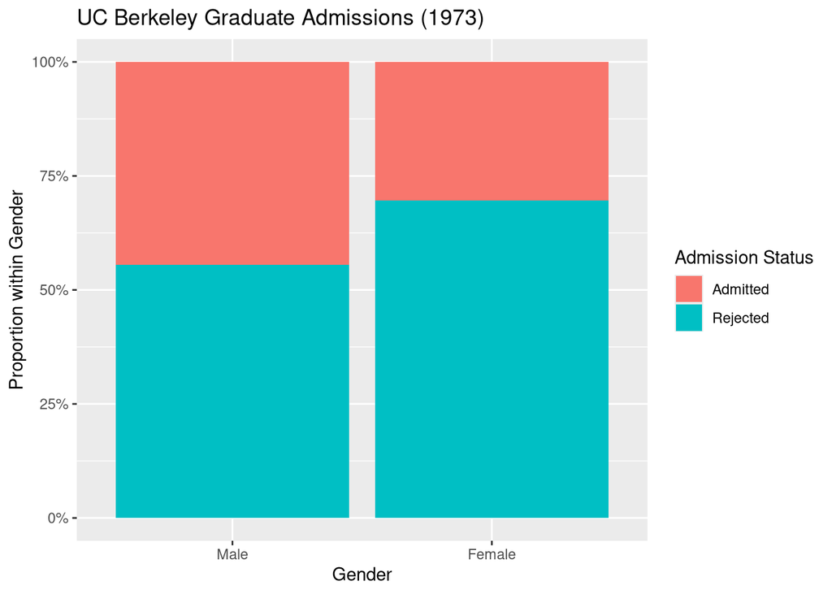

```r
# Convert table to dataframe
ucb_df <- as.data.frame(UCBAdmissions)

# Aggregate across departments
agg_df <- ucb_df |>
  group_by(Gender, Admit) |>
  summarise(Freq = sum(Freq), .groups = "drop") |>
  mutate(Prop = Freq / sum(Freq))

# Plot: proportion admitted by gender
ggplot(agg_df, aes(x = Gender, y = Prop, fill = Admit)) +
  geom_col(position = "fill") +
  scale_y_continuous(labels = scales::percent) +
  labs(
    title = "UC Berkeley Graduate Admissions (1973)",
    y = "Proportion within Gender",
    x = "Gender",
    fill = "Admission Status"
  )
```

The above plot shows you that women are more likely to be rejected from University of California - Berkely (UCB) than men. Please take some time to ensure that you understand how the plot backs up that claim.

### Question 1

Suppose an uninformed viewer of this plot makes the claim “we should discourage women from applying to UCB since there applications are less competitive than male applicants.”

STOP here Go to Canvas Answer Quiz question 1: why this claim is problematic

Resume after quiz question 1 is answered.

Now, consider the plot created by the code below

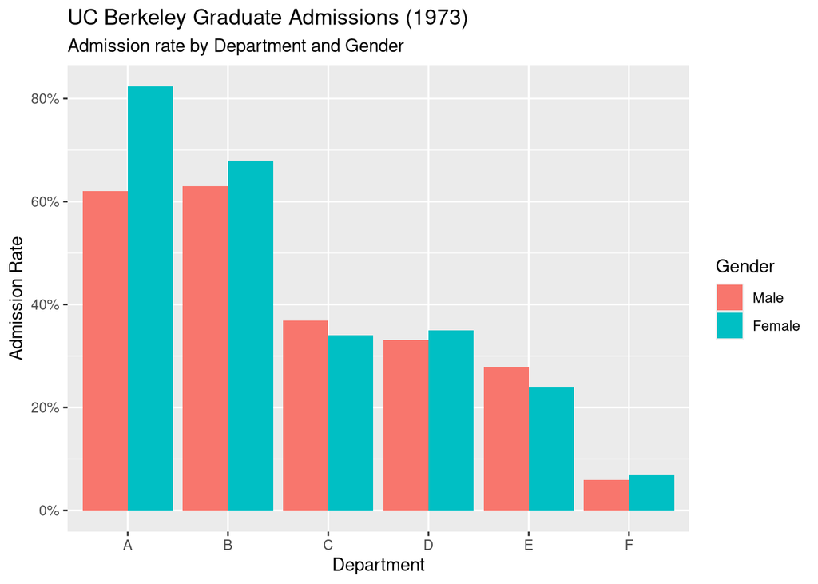

```r
dept_df <- ucb_df |>
  group_by(Dept, Gender, Admit) |>
  summarise(Freq = sum(Freq), .groups = "drop") |>
  group_by(Dept, Gender) |>
  mutate(Total = sum(Freq),
         Rate = Freq / Total) |>
  filter(Admit == "Admitted")

# Plot admission rates by department and gender
ggplot(dept_df, aes(x = Dept, y = Rate, fill = Gender)) +
  geom_col(position = "dodge") +
  scale_y_continuous(labels = scales::percent) +
  labs(
    title = "UC Berkeley Graduate Admissions (1973)",
    subtitle = "Admission rate by Department and Gender",
    x = "Department",
    y = "Admission Rate",
    fill = "Gender"
  )
```

### Question 2

Before how this happened, another uninformed reader says “we should force the male and female application rates to be exactly the same in order to ensure fairness.”

STOP here Go to Canvas Answer Quiz question 2: why this claim is problematic

Resume after quiz question 2 is answered.

## Putting it all together

The final code helps to demystify the issue:

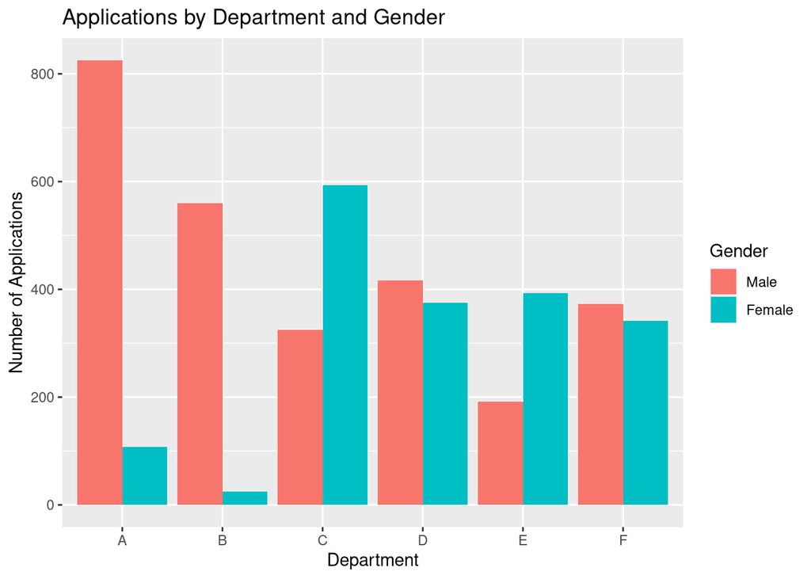

```r
# Total applications by department and gender
apps_df <- ucb_df |>
  group_by(Dept, Gender) |>
  summarise(Applications = sum(Freq), .groups = "drop") |>
  group_by(Gender) |>
  mutate(Share = Applications / sum(Applications))

# Plot 1: raw counts of applications
ggplot(apps_df, aes(x = Dept, y = Applications, fill = Gender)) +
  geom_col(position = "dodge") +
  labs(
    title = "Applications by Department and Gender",
    x = "Department",
    y = "Number of Applications",
    fill = "Gender"
  )
```

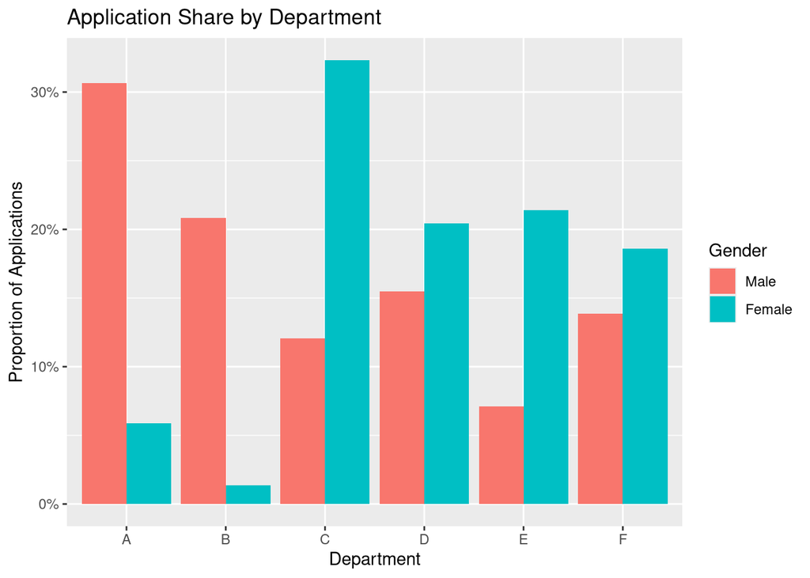

```r
# Plot 2: proportion of each gender's applications going to each department
ggplot(apps_df, aes(x = Dept, y = Share, fill = Gender)) +
  geom_col(position = "dodge") +
  scale_y_continuous(labels = scales::percent) +
  labs(
    title = "Application Share by Department",
    x = "Department",
    y = "Proportion of Applications",
    fill = "Gender"
  )
```

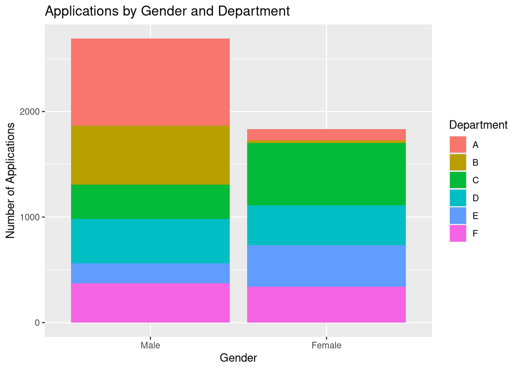

```r
# Plot 3: raw numbers of each gender's applications going to each department
ggplot(ucb_df, aes(x = Gender, weight = Freq, fill = Dept)) + geom_bar(position = "stack") +
  labs(
    title = "Applications by Gender and Department",
    x = "Gender",
    y = "Number of Applications",
    fill = "Department"
  )
```

Thus, the answer to “Simpson’s Paradox” is this: the reason that women appear to be admitted at a lower rate than men is because women were disproportionately more likely to apply to more selective departments. More importantly, this assignment reminded you that not all decisions can be effectively or ethically made with data alone.